# cycleGan_weatherTransfer

Chenhao Zhu, Hua Zhong, Yifei Wu

Colab Link : https://colab.research.google.com/drive/11STlEQttHiJV3vPkDL_DO3roBVE0E-nQ#scrollTo=8ozAmRYsepHk

```python
import argparse
import math
import time

import matplotlib
import matplotlib.pyplot as plt
import numpy as np
import numpy.random as npr
import scipy.misc
import torch
import torch.nn as nn
import torch.nn.functional as F
from torch.autograd import Variable
import pandas as pd
```

```python
from google.colab import drive
drive.mount('/content/drive')
```

```python
import torchvision.datasets as dset
import os
import numpy as np
import torch
import torchvision
from torchvision import datasets, models, transforms
import matplotlib.pyplot as plt
```

# **Reading the data we used.**

- We will only make use of two data types, the first is rainy and the seond is cloudy.
- Our primary goal is to de-rain or de-fog. Among discussion, we think that these two tasks could be combined into one. Once we finish de-rain, de-fog is just changing the input image.

```python
data_transform = transforms.Compose([transforms.Resize((224,224)),
                                      transforms.ToTensor()
                                     ])
dataset1 = dset.ImageFolder('/content/drive/MyDrive/whetherClassficiation/Rainy-data', transform=data_transform)
dataset2 = dset.ImageFolder('/content/drive/MyDrive/whetherClassficiation/cloudy-data', transform=data_transform)
```

```python
classes1 = dataset1.classes
print(classes1)
print(dataset1.class_to_idx)
print(len(dataset1.imgs))

classes2 = dataset2.classes
print(classes2)
print(dataset2.class_to_idx)
print(len(dataset2.imgs))
```

```
['rainy']
{'rainy': 0}
300
['cloudy']
{'cloudy': 0}
300
```

```python
# dataloader for batching samples

def get_batch(x, y, batch_size):
    """
    Generated that yields batches of data

    Args:
      x: input values
      y: output values
      batch_size: size of each batch
    Yields:
      batch_x: a batch of inputs of size at most batch_size
      batch_y: a batch of outputs of size at most batch_size
    """
    N = np.shape(x)[0]
    assert N == np.shape(y)[0]
    for i in range(0, N, batch_size):
        batch_x = x[i : i + batch_size, :, :, :]
        batch_y = y[i : i + batch_size, :, :, :]
        yield (batch_x, batch_y)
```

```python
train_data1, val_data1 = torch.utils.data.random_split(dataset1, [250, 50])
train_data2, val_data2 = torch.utils.data.random_split(dataset2, [250, 50])

print(len(train_data1))
print(len(val_data1))
# print(len(test_data))

# define dataloader parameters
batch_size  = 10
num_workers = 1

# prepare data loaders
train_loader1 = torch.utils.data.DataLoader(train_data1, batch_size=batch_size,
                                           num_workers=num_workers, shuffle=True)
val_loader1 = torch.utils.data.DataLoader(val_data1, batch_size=batch_size,
                                          num_workers=num_workers, shuffle=True)

train_loader2 = torch.utils.data.DataLoader(train_data2, batch_size=batch_size,
                                           num_workers=num_workers, shuffle=True)
val_loader2 = torch.utils.data.DataLoader(val_data2, batch_size=batch_size,
                                          num_workers=num_workers, shuffle=True)
# test_loader = torch.utils.data.DataLoader(val_data, batch_size=batch_size,
#                                           num_workers=num_workers, shuffle=True)
print(train_loader1)
```

```
250
50
<torch.utils.data.dataloader.DataLoader object at 0x7f387e936a90>
```

```python
train_loader1 = torch.utils.data.DataLoader(dataset1, batch_size=batch_size,
                                           num_workers=num_workers, shuffle=True)
train_loader2 = torch.utils.data.DataLoader(dataset2, batch_size=batch_size,
                                           num_workers=num_workers, shuffle=True)
```

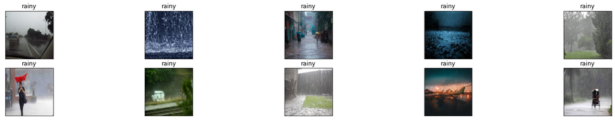

```python
# Visualize some sample data

# obtain one batch of training images
dataiter = iter(train_loader1)
images, labels = next(dataiter)
images = images.numpy() # convert images to numpy for display

# plot the images in the batch, along with the corresponding labels
fig = plt.figure(figsize=(25, 4))
for idx in np.arange(10):
    ax = fig.add_subplot(2, 10/2, idx+1, xticks=[], yticks=[])
    plt.imshow(np.transpose(images[idx], (1, 2, 0)))
    ax.set_title(classes1[labels[0]])
```

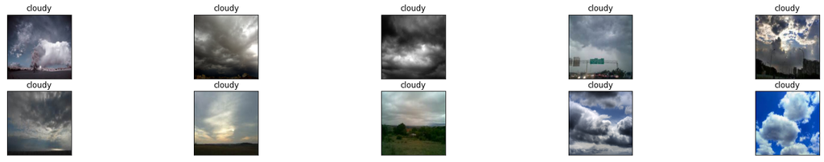

```python
# Visualize some sample data

# obtain one batch of training images
dataiter = iter(train_loader2)
images, labels = next(dataiter)
images = images.numpy() # convert images to numpy for display

# plot the images in the batch, along with the corresponding labels
fig = plt.figure(figsize=(25, 4))
for idx in np.arange(10):
    ax = fig.add_subplot(2, 10/2, idx+1, xticks=[], yticks=[])
    plt.imshow(np.transpose(images[idx], (1, 2, 0)))
    ax.set_title(classes2[labels[0]])
```

# **Define a generator model to test whether it works**

```python
class RegressionCNN(nn.Module):
    def __init__(self, kernel, num_filters):
        # first call parent's initialization function
        super().__init__()
        padding = kernel // 2

        self.downconv1 = nn.Sequential(
            nn.Conv2d(3, num_filters, kernel_size=kernel, padding=padding),
            nn.BatchNorm2d(num_filters),
            nn.ReLU(),
            nn.MaxPool2d(2),)
        self.downconv2 = nn.Sequential(
            nn.Conv2d(num_filters, num_filters*2, kernel_size=kernel, padding=padding),
            nn.BatchNorm2d(num_filters*2),
            nn.ReLU(),
            nn.MaxPool2d(2),)

        self.rfconv = nn.Sequential(
            nn.Conv2d(num_filters*2, num_filters*2, kernel_size=kernel, padding=padding),
            nn.BatchNorm2d(num_filters*2),
            nn.ReLU())

        self.upconv1 = nn.Sequential(
            nn.Conv2d(num_filters*2, num_filters, kernel_size=kernel, padding=padding),
            nn.BatchNorm2d(num_filters),
            nn.ReLU(),
            nn.Upsample(scale_factor=2),)
        self.upconv2 = nn.Sequential(
            nn.Conv2d(num_filters, 3, kernel_size=kernel, padding=padding),
            nn.BatchNorm2d(3),
            nn.ReLU(),
            nn.Upsample(scale_factor=2),)
        self.finalconv = nn.Conv2d(3, 3, kernel_size=kernel, padding=padding)

    def forward(self, x):
        out = self.downconv1(x)
        out = self.downconv2(out)
        out = self.rfconv(out)
        out = self.upconv1(out)
        out = self.upconv2(out)
        out = self.finalconv(out)
        return out
```

```python
class AttrDict(dict):
    def __init__(self, *args, **kwargs):
        super(AttrDict, self).__init__(*args, **kwargs)
        self.__dict__ = self

# dataloader for batching samples

def get_batch(x, y, batch_size):
    """
    Generated that yields batches of data

    Args:
      x: input values
      y: output values
      batch_size: size of each batch
    Yields:
      batch_x: a batch of inputs of size at most batch_size
      batch_y: a batch of outputs of size at most batch_size
    """
    N = np.shape(x)[0]
    assert N == np.shape(y)[0]
    for i in range(0, N, batch_size):
        batch_x = x[i : i + batch_size, :, :, :]
        batch_y = y[i : i + batch_size, :, :, :]
        yield (batch_x, batch_y)

def get_torch_vars(xs, ys, gpu=False):
    """
    Helper function to convert numpy arrays to pytorch tensors.
    If GPU is used, move the tensors to GPU.

    Args:
      xs (float numpy tenosor): greyscale input
      ys (int numpy tenosor): rgb as labels
      gpu (bool): whether to move pytorch tensor to GPU
    Returns:
      Variable(xs), Variable(ys)
    """
    xs = torch.from_numpy(xs).float()
    ys = torch.from_numpy(ys).float()
    if gpu:
        xs = xs.cuda()
        ys = ys.cuda()
    return Variable(xs), Variable(ys)

def train(args, gen=None):

    # Numpy random seed
    npr.seed(args.seed)

    # Save directory
    save_dir = "outputs/" + args.experiment_name

    # LOAD THE MODEL
    if gen is None:
        Net = globals()[args.model]
        gen = Net(args.kernel, args.num_filters)

    # LOSS FUNCTION
    criterion = nn.MSELoss()
    optimizer = torch.optim.Adam(gen.parameters(), lr=args.learn_rate)

    # # DATA
    # print("Loading data...")
    # (x_train, y_train), (x_test, y_test) = load_cifar10()

    # print("Transforming data...")
    # train_rgb, train_grey = process(x_train, y_train, downsize_input=args.downsize_input)
    # test_rgb, test_grey = process(x_test, y_test, downsize_input=args.downsize_input)

    # Create the outputs folder if not created already
    if not os.path.exists(save_dir):
        os.makedirs(save_dir)

    print("Beginning training ...")
    if args.gpu:
        gen.cuda()
    start = time.time()

    train_losses = []
    valid_losses = []
    valid_accs = []
    ep = []
    n = 0
    losses = []
    for epoch in range(args.epochs):
        time0 = time.time()
        epochC = epoch + 1
        print(f' ---------- On epoch {epochC} ---------- ')
        # Train the Model
        gen.train()  # Change model to 'train' mode

        for imgs, labels in iter(train_loader1) :#for i, (xs, ys) in enumerate(get_batch(dataset1, dataset2, args.batch_size)):
            # images, labels = get_torch_vars(xs, ys, args.gpu)
            # Forward + Backward + Optimize
            dataiter = iter(train_loader2)
            imgs2, labels2 = dataiter.next()
            optimizer.zero_grad()
            # print(imgs.shape)
            if args.gpu :#torch.cuda.is_available():
                # print('GPU kai le')
                # gen.cuda()
                imgs = imgs.cuda()
                imgs2 = imgs2.cuda()
                labels = labels.cuda()
                labels2 = labels2.cuda()

            outputs = gen(imgs)
            # print(outputs.shape, imgs2.shape)
            try :
                loss = criterion(outputs, imgs2)
                loss.backward()
                optimizer.step()
                #losses.append(loss.data.item())
                optimizer.zero_grad()
            except :
                pass

            #ep.append(n)

            n += 1
        ep.append(epoch)
        losses.append(loss.data.item())
        t = time.time() - time0
        print(f' ------------------------------------ Epoch {epochC} fininshed in {t} seconds')


        print(epoch, loss.cpu().detach())
        print(imgs.shape, labels.shape, outputs.shape)
        if args.plot:
          visual(imgs, imgs2, outputs, args.gpu, 1)
    # print(ep)
    # print(losses)
    plt.title("Training Curve")
    plt.plot(ep, losses, label="Train")
    plt.xlabel("Epoches")
    plt.ylabel("Loss")
    plt.show()

    # plt.title("Training Curve")
    # plt.plot(ep, train_acc, label="Train")
    # plt.xlabel("Iterations")
    # plt.ylabel("Training Accuracy")
    # plt.legend(loc='best')
    # plt.show()

    return gen

# visualize 5 train/test images
def visual(img_1, img_2, img_fake, gpu = 0, flag_torch = 0):
  plt.figure(figsize = (16, 8))
  if gpu:
    img_1 = img_1.cpu().detach()
    img_2 = img_2.cpu().detach()
    img_fake = img_fake.cpu().detach()

  if flag_torch:
    img_1 = img_1.numpy()
    img_2 = img_2.numpy()
    img_fake = img_fake.numpy()

  if flag_torch == 2:
    img_2 = np.transpose(img_2[:, :, :, :, :], [0, 4, 2, 3, 1]).squeeze()
    img_fake = np.transpose(img_fake[:, :, :, :, :], [0, 4, 2, 3, 1]).squeeze()

  for i in range(5):
      ax1 = plt.subplot(3, 5, i + 1)
      # ax.imshow(img_1[i], cmap='gray')
      ax1.imshow(np.transpose(img_1[i], (1, 2, 0)))
    #   ax.axis("off")
      ax2 = plt.subplot(3, 5, i + 1 + 5)
      ax2.imshow(np.transpose(img_2[i], (1, 2, 0)))
    #   ax.imshow(img_2[i])
    #   ax.axis("off")
      ax3 = plt.subplot(3, 5, i + 1 + 10)
      # ax.imshow(img_fake[i])
      ax3.imshow(np.transpose(img_fake[i], (1, 2, 0)))
    #   ax.axis("off")
  plt.show()

#Main training loop for CNN
# args = AttrDict()
# args_dict = {
#     "gpu": True,
#     "valid": False,
#     "checkpoint": "",
#     "colours": "./data/colours/colour_kmeans24_cat7.npy",
#     "model": "RegressionCNN",
#     "kernel": 3,
#     "num_filters": 32,
#     'learn_rate':0.001,
#     "batch_size": 100,
#     "epochs": 2,
#     "seed": 0,
#     "plot": True,
#     "experiment_name": "colourization_cnn",
#     "visualize": False,
#     "downsize_input": False,
# }

# dev=torch.device("cuda")
# args.update(args_dict)
# cnn = train(args)
```

# **Define the Generator and Discriminator for weather changing.**

- Cyclegan has two generators, now we just make these two generators the same structure, which make use of skip connection to avoid gradient vanishing.
- For discriminator, we just use fully connected layers with appropriate drop-out.

```python
class GeneratorSkip(nn.Module):
    def __init__(self, kernel=3, num_filters=32, num_colours=3, num_in_channels=3):
        super().__init__()
        # Useful parameters
        stride = 2
        padding = kernel // 2
        output_padding = 1
        ############### YOUR CODE GOES HERE ###############
        ###################################################
        self.downconv1 = nn.Sequential(
            nn.Conv2d(num_in_channels, num_filters, kernel_size=kernel, padding=padding),
            nn.BatchNorm2d(num_filters),
            nn.ReLU(),
            nn.MaxPool2d(2),)
        self.downconv2 = nn.Sequential(
            nn.Conv2d(num_filters, num_filters*2, kernel_size=kernel, padding=padding),
            nn.BatchNorm2d(num_filters*2),
            nn.ReLU(),
            nn.MaxPool2d(2),)
        self.rfconv = nn.Sequential(
            nn.Conv2d(num_filters*2, num_filters*2, kernel_size=kernel, padding=padding),
            nn.BatchNorm2d(num_filters*2),
            nn.ReLU())
        self.upconv1 = nn.Sequential(
            nn.Conv2d(2 * num_filters*2, num_filters, kernel_size=kernel, padding=padding),
            nn.BatchNorm2d(num_filters),
            nn.ReLU(),
            nn.Upsample(scale_factor=2),)
        self.upconv2 = nn.Sequential(
            nn.Conv2d(2 * num_filters, num_colours, kernel_size=kernel, padding=padding),
            nn.BatchNorm2d(num_colours),
            nn.ReLU(),
            nn.Upsample(scale_factor=2),)
        self.finalconv = nn.Conv2d(num_in_channels + num_colours, num_colours, kernel_size=kernel, padding=output_padding)


    def forward(self, x):
        ############### YOUR CODE GOES HERE ###############
        ###################################################
        out1 = self.downconv1(x)
        out2 = self.downconv2(out1)
        out3 = self.rfconv(out2)

        input4 = torch.cat((out2, out3), 1)
        out4 = self.upconv1(input4)

        input5 = torch.cat((out1, out4), 1)
        out5 = self.upconv2(input5)

        input6 = torch.cat((x, out5), 1)
        out = self.finalconv(input6)

        return out
```

```python
# discriminator code

class Discriminator(nn.Module):
    def __init__(self, kernel, num_filters, num_colours=3, num_in_channels=1):
        super().__init__()
        self.label_emb = nn.Embedding(10, 10)

        # Useful parameters
        stride = 2
        padding = kernel // 2
        output_padding = 1

        self.model = nn.Sequential(
            nn.Linear(224*224*3, 512),
            nn.LeakyReLU(0.2, inplace=True),
            nn.Dropout(0.3),
            nn.Linear(512, 256),
            nn.LeakyReLU(0.2, inplace=True),
            nn.Dropout(0.3),
            nn.Linear(256, 1),
            nn.Sigmoid()
        )

        ############### YOUR CODE GOES HERE ###############
        ###################################################
    def forward(self, x):
        #print(x.shape)
        # x = torch.cat([x, c], 1)
        x = x.view(x.size(0), 224*224*3)
        #print(x.shape)
        # c = self.label_emb(labels)
        # x = torch.cat([x, c], 1)
        out = self.model(x)
        return out.squeeze()
```

Here we test whether our discriminator works

```python
criterion =  nn.BCELoss()
discriminator = Discriminator(kernel = 3, num_filters = 16).cuda()
for imgs, labels in iter(train_loader1) :
    # images, labels = get_torch_vars(xs, ys, args.gpu)
    batch_size = 10
    imgs = imgs.cuda()
    print(imgs.shape)
    real_validity = discriminator(imgs)
    real_loss = criterion(real_validity, Variable(torch.ones(10)).cuda())
    print(real_validity)
    break
```

```
torch.Size([10, 3, 224, 224])
tensor([0.4781, 0.4891, 0.4678, 0.4630, 0.4706, 0.5020, 0.4841, 0.4830, 0.4642,
        0.4825], device='cuda:0', grad_fn=<SqueezeBackward0>)
```

```python
exit()
```

# **Run the Train codes to finalize the model**

- For cyclegan algorithm, the most important part is the loss function because it contains two generators and potentially more than 1 discriminator.
- In the training part, we first train the first generator to make rainy image to cloudy image, and then transform de-rainy image to rainy image; Second, we use the second generator to make cloudy image to rainy image, and then transform rainy image to cloudy image. In such a loop, we simply implement the idea of cyclegan.
- For our cyclegan model. We do not get a satisfied version because it do not change the origiinal image very well. Thus we think that it may because that the process in train function has some mis-understanding. We will spend time on that in the future.

```python
def train2(args, gen=None):

    # Numpy random seed
    npr.seed(args.seed)

    # Save directory
    save_dir = "outputs/" + args.experiment_name

    # LOAD THE MODEL
    if gen is None:
        Net1 = globals()[args.model1]
        generator1 = Net1(args.kernel, args.num_filters)
        generator2 = Net1(args.kernel, args.num_filters)
        Net2 = globals()[args.model2]
        discriminator = Net2(args.kernel, args.num_filters)

    # LOSS FUNCTION
    criterion = nn.MSELoss()
    disloss = nn.L1Loss()
    g_optimizer_1 = torch.optim.Adam(generator1.parameters(), lr=1e-4)
    g_optimizer_2 = torch.optim.Adam(generator2.parameters(), lr=1e-4)
    d_optimizer = torch.optim.Adam(discriminator.parameters(), lr=1e-4)

    # Create the outputs folder if not created already
    if not os.path.exists(save_dir):
        os.makedirs(save_dir)

    print("Beginning training ...")
    if args.gpu:
        generator1.cuda()
        generator2.cuda()
        discriminator.cuda()
    start = time.time()

    train_losses = []
    valid_losses = []
    valid_accs = []
    gloss_1 = []
    gloss_2 = []
    dloss = []
    ep = []
    n = 0
    losses = []
    for epoch in range(args.epochs):
        time0 = time.time()
        epochC = epoch + 1
        print(f' ---------- On epoch {epochC} ---------- ')
        # Train the Model
        # gen.train()  # Change model to 'train' mode

        for imgs, labels in iter(train_loader1) :#for i, (xs, ys) in enumerate(get_batch(dataset1, dataset2, args.batch_size)):
            # images, labels = get_torch_vars(xs, ys, args.gpu)
            # Forward + Backward + Optimize
            dataiter = iter(train_loader2)
            imgs2, labels2 = dataiter.next()

            batch_size = args.batch_size
            # print(imgs.shape)
            if args.gpu :#torch.cuda.is_available():
                # print('GPU kai le')
                # gen.cuda()
                imgs = imgs.cuda()
                imgs2 = imgs2.cuda()
                labels = labels.cuda()
                labels2 = labels2.cuda()
            # #discriminator training
            # d_optimizer.zero_grad()
            # # print(img_real.shape)
            # # print(labels.shape)
            # real_validity = discriminator(imgs)
            # real_loss = disloss(real_validity, Variable(torch.ones(batch_size)).cuda())
            # # fake_labels = Variable(torch.LongTensor(img_real)).cuda()
            # # fake_labels = img_real.cuda()
            # fake_images = generator1(imgs)
            # fake_validity = discriminator(fake_images)
            # fake_loss = disloss(fake_validity, Variable(torch.zeros(batch_size)).cuda())
            # d_loss = real_loss + fake_loss

            # d_loss.backward()
            # d_optimizer.step()
            #discriminator training
            d_optimizer.zero_grad()

            disreal_1 = discriminator(imgs)
            disreal_2 = discriminator(imgs2)
            fake_images = generator1(imgs)
            fake_images_2 = generator2(imgs2)
            disfake_1 = discriminator(fake_images)
            disfake_2 = discriminator(fake_images_2)
            disreal_1_loss = disloss(disreal_1, Variable(torch.ones(batch_size).cuda()))
            disreal_2_loss = disloss(disreal_2, Variable(torch.ones(batch_size).cuda()))
            disfake_1_loss = disloss(disfake_1, Variable(torch.zeros(batch_size).cuda()))
            disfake_2_loss = disloss(disfake_2, Variable(torch.zeros(batch_size).cuda()))


            d_loss = disreal_1_loss + disreal_2_loss + disfake_1_loss + disfake_2_loss

            d_loss.backward()
            d_optimizer.step()
            d_optimizer.zero_grad()


            # generator training
            g_optimizer_1.zero_grad()
            fake_images = generator1(imgs)
            cycle_images = generator2(fake_images)
            # cyclegan second generator training

            fake_images_2 = generator2(imgs2)
            cycle_images_2 = generator1(fake_images_2)

            identy_1 = generator2(imgs)
            identy_2 = generator1(imgs2)

            # two result from discriminators on four pictures, two real images, two fake images

            g_loss_1 = criterion(fake_images, imgs)
            g_loss_2 = criterion(fake_images_2, imgs2)
            total_cycle_loss = criterion(cycle_images, imgs) + criterion(cycle_images_2, imgs2)

            identityLoss_1 = criterion(identy_2, imgs2)
            identityLoss_2 = criterion(identy_1, imgs)


            total_gen_1_loss = g_loss_1 + total_cycle_loss + identityLoss_1
            total_gen_1_loss.backward()
            g_optimizer_1.step()
            g_optimizer_1.zero_grad()

            g_optimizer_2.zero_grad()
            fake_images = generator1(imgs)
            cycle_images = generator2(fake_images)
            # cyclegan second generator training

            fake_images_2 = generator2(imgs2)
            cycle_images_2 = generator1(fake_images_2)

            identy_1 = generator2(imgs)
            identy_2 = generator1(imgs2)

            # two result from discriminators on four pictures, two real images, two fake images

            g_loss_1 = criterion(fake_images, imgs)
            g_loss_2 = criterion(fake_images_2, imgs2)
            total_cycle_loss = criterion(cycle_images, imgs) + criterion(cycle_images_2, imgs2)

            identityLoss_1 = criterion(identy_2, imgs2)
            identityLoss_2 = criterion(identy_1, imgs)
            total_gen_2_loss = g_loss_2 + total_cycle_loss + identityLoss_2
            total_gen_2_loss.backward()
            g_optimizer_2.step()
            g_optimizer_2.zero_grad()





            # g_loss = abs(0.5 * g_loss_1 + 0.5 * g_loss_2)
            # print(total_gen_1_loss, total_gen_2_loss, d_loss)



            #ep.append(n)

            n += 1
        ep.append(epoch)
        gloss_1.append(total_gen_1_loss.data.item())
        gloss_2.append(total_gen_2_loss.data.item())
        dloss.append(d_loss.data.item())
        t = time.time() - time0
        print(f' ------------------------------------ Epoch {epochC} fininshed in {t} seconds')


        # print(epoch, total_gen_1_loss.cpu().detach(), total_gen_1_loss.cpu().detach(), d_loss.cpu().detach())
        # print(imgs.shape, imgs.shape, new_fake_images.shape)
        if args.plot:
          visual(imgs, imgs2, fake_images, args.gpu, 1)
    # print(ep)
    # print(losses)
    plt.title("Training Curve")
    plt.plot(ep, gloss_1, label="Generator1")
    plt.plot(ep, gloss_2, label="Generator2")
    plt.plot(ep, dloss, label="Discriminator")
    plt.xlabel("Epoches")
    plt.ylabel("Loss")
    plt.legend(loc='best')
    plt.show()

    # plt.title("Training Curve")
    # plt.plot(ep, train_acc, label="Train")
    # plt.xlabel("Iterations")
    # plt.ylabel("Training Accuracy")
    # plt.legend(loc='best')
    # plt.show()

    return generator1

def visual(img_1, img_2, img_fake, gpu = 0, flag_torch = 0):
  plt.figure(figsize = (16, 8))
  if gpu:
    img_1 = img_1.cpu().detach()
    img_2 = img_2.cpu().detach()
    img_fake = img_fake.cpu().detach()

  if flag_torch:
    img_1 = img_1.numpy()
    img_2 = img_2.numpy()
    img_fake = img_fake.numpy()

  if flag_torch == 2:
    img_2 = np.transpose(img_2[:, :, :, :, :], [0, 4, 2, 3, 1]).squeeze()
    img_fake = np.transpose(img_fake[:, :, :, :, :], [0, 4, 2, 3, 1]).squeeze()

  for i in range(5):
      ax1 = plt.subplot(3, 5, i + 1)
      # ax.imshow(img_1[i], cmap='gray')
      ax1.imshow(np.transpose(img_1[i], (1, 2, 0)))
    #   ax.axis("off")
      ax2 = plt.subplot(3, 5, i + 1 + 5)
      ax2.imshow(np.transpose(img_2[i], (1, 2, 0)))
    #   ax.imshow(img_2[i])
    #   ax.axis("off")
      ax3 = plt.subplot(3, 5, i + 1 + 10)
      # ax.imshow(img_fake[i])
      ax3.imshow(np.transpose(img_fake[i], (1, 2, 0)))
    #   ax.axis("off")
  plt.show()



args = AttrDict()
args_dict = {
    "gpu": True,
    "valid": False,
    "checkpoint": "",
    "colours": "./data/colours/colour_kmeans24_cat7.npy",
    "model1": "GeneratorSkip",
    'model2' : 'Discriminator',
    "kernel": 3,
    "num_filters": 32,
    'learn_rate':0.001,
    "batch_size": 10,
    "epochs": 100,
    "seed": 0,
    "plot": True,
    "experiment_name": "colourization_cnn",
    "visualize": False,
    "downsize_input": False,
}

args.update(args_dict)
cnn = train2(args)
```

```
Output hidden; open in https://colab.research.google.com to view.
```

```python
exit()
```